# Session 2: Probability, Odds and related things

Author

Chris Mainey

Published

20 June 2025

# Introduction

This session discusses how we can use statistics to infer things from data, commonly known as *statistical inference*. Statistical inference is built, however on *probability theory*, so we will spend much of this session discussing that, thinking about what probability means, and some of the common representations of it as probability ratios, relative risk, and odds ratios.

## Terminology

Some of the terminology might get a bit overwhelming here, but the main things to be aware of are:

- **Experiment / Trial / Event:** The number of times something is conducted, e.g. a dice role or coin toss.
- **Outcome:** The possible result we are interested in. E.g. death, developing a disease
- **Exposure:** Groups that are systematically different who’s outcomes we might be interested in. This might be in-terms of receiving a treatment, or having a risk factor. E.g. Amputations in diabetics v.s. non-diabetics, or deaths in groups who received a drug vs. those who didn’t.
- *A-priori probability:* This is classical ‘known’ probability. E.g. likelihood of a particular dice role, given 6 sides.
- *Empirical probability:* Based solely on our observations, not fully ‘known’

## Notation

We will use a bit of algebraic notation in this section… *it’s not as hard as it looks on first glance!*.

### Algebraic notation

We will use $P$ to mean the probability of something some event that we might name $A$, and this will look like $P(A)$. We will commonly talk about two events: $A$ and $B$.

### 2 x 2 tables

We will also use a standard sort of table from epidemiology/statistics. The ‘2x2 table’ is 2 rows * 2 columns, and allow us to compare outcomes (events, intervention, what happened etc.) in groups (exposure, cohort):

|  | O(+) | O(-) |
| --- | --- | --- |
| E+ | a | b |
| E- | c | d |

- E = ‘Exposure’, meaning how the groups differ
- O = Outcome, what were the different results in groups

# Probability

Probability is a way of quantifying events, and how likely they are to happen. This might be in a closed, or **a-priori** system (like a dice role), or an open, or **empirical**, system (how likely is it that a patient dies in hospital).

We usually describe this as the number of times an event is likely to occur, out of the number of possible events.

$$P(A) = \frac{\text{Number of outcomes making up event (A)}}{\text{Total number of outcomes}}$$

If we consider flipping a fair coin:

$$P(heads) = \frac{(1 * heads)}{(1* heads) + (1 * tails)} = \frac{1}{2} = 0.5$$

If we consider a fair dice (die) roll, what is the probability of any given number, e.g. 6:

$$P(number) = \frac{(1 * number)}{\text{6 possible numbers}} = \frac{1}{6} = 0.16\dot{6}$$

If we consider drawing a queen in a full deck of cards (no jokers):

$$P(\text{queen}) = \frac{(4 * \text{queen})}{(52 * cards)} = \frac{4}{52} = \frac{1}{13} = 0.077$$

## Actvity: Dice rolling

Roll 2 dice at least 24 times and note them down. Write each possible number down: 1 - 12, and make a tally of each roll.

**What do you see?**

**How would you calculate the probability of rolling each number?**

This is the *Empirical probability*, as we are calculating it from a sample, not in theory.

**What is the probability of rolling any given number on each die?**

## Types of probablity

Our simple examples so far have been easy to understand, as they have been single events in isolation. We need to add a few more descriptions around situations to distinguish what is going on and how that affects us when there is more than one thing we are interested it.

### Exclusivity

If we have more than one event, but one event prevents any other, we refer to it as exclusive ‘exclusive’. For example, a coin toss of heads is exclusive, and it cannot be tails at the same time. If it is one, it is not the other. This is the case for both heads and tails, so we can call it *mutually exclusive*.

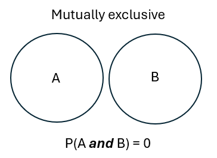

**i.e. There is 0 zero change of both events at the same time. Being one prevents being the other.**

### Exhaustivity

If we have accounted for all possible outcomes, we can consider the options ‘exhausted.’ E.g. with the coin toss, both options of heads and tails account for all the options, so we would consider that exhaustive and, as with exclusivity, it is also mutually exhaustive.

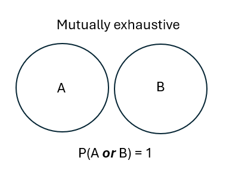

**i.e. one of them definitely happens**

It is possible to be both mutually exhaustive and mutually exclusive, like our coin example. Many real world applications are not, e.g. the probability of an individual being female and having brown hair are neither exclusive or exhaustive.

### Exercises:

What are these two situations? First try and answer the questions before looking up the answers on the tabs.

**Questions**

1. Rolling a die and getting either an even number, or any number except 2.
2. Rolling a die and getting either an even number, or any number except 3.

**1.**

**Exhaustive, not mutually exclusive** Rolling a 4 or a 6 are both even, but the set contains all results.

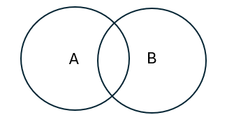

**2**

**It’s complicated** Considering A & B, it’s not exhaustive nor exclusive.

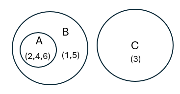

### Independence / Conditionality

When we are considering more than one event, we have to assess whether or not they are related. There are two main ways in which they can be related:

- If two events **do not** have effects on each other, then they can be considered to be *independent*. E.g. two coin tosses are perfectly isolated, and the previous toss does not affect it, nor does the subsequent coin toss. Both coin tosses
- If one event has an effect on the subsequent outcomes, then they are considered *conditional*. E.g. probability of drawing two consecutive red M&M from a bag that contains two blue and five red M&Ms left:

Draw 1 = $P(red) = \frac{5 * red}{(5 * red) + (2 * blue)} = \frac{5}{7} = 0.71$

*You drew a red.*

Draw 2 = $P(red) = \frac{4 * red}{(4 * red) + (2 * blue)} = \frac{4}{6} = 0.6\dot{6}$

**What would happen if you replaced the red M&M in the bag before the second draw?**

< **How would you describe this situation now?**

We can update our notation to use the `|` which indicates conditional probability: $P(B|A)$ So the probability of B, given that A has happened.

This leads us to useful formula for the probability of A and B:

$$P(\text{A and B}) = P(A) * P(B|A)$$
Applied to our M&Ms, with Draw 1 and Draw 2, the probability of drawing two reds is:

$$P(\text{Draw 2 | Draw 1}) = P(\text{Draw 1}) * P(\text{Draw 2 | Draw 1})) = \frac{5}{7} * \frac{4}{6} = 0.48$$

## Combining probabilities

We often want to combine probabilities together to get different values, once we’ve decided how they are related. This can be done with regular maths, with care as to whether things are independent or conditional. In all the examples below, the first event is A, and second is B.

Both of these depend on whether it is mutually exclusive, and whether indecent.

- **Union:** The probability of either A **OR** B: $P(A\cup B) = P(A) + P(B) - P(A\cap B)$
- **Intersection:** The probability of A **AND** B. $P(A\cap B) = P(A) * P(B)$ for independent data, you commonly need to work out all possible outcomes, and potentially draw a tree diagram, for more complicated situations

E.g.

$$P(\text{at least one heads}) = \frac{1}{2} + \frac{1}{2} - \frac{1}{4} = 0.75$$

Probability of tossing two coins **AND** getting two heads. They are mutually exclusive, exhaustive & independent. This is an Intersection:

$$P(\text{Heads * 2}) = \frac{1}{2} * \frac{1}{2} = \frac{1}{4}$$

**Task**

**Calculate the probability of rolling two 3’s with a fair, six-sided die**

**Task** **Calculate the (a-priori) probability of rolling a total of 8 with two rolls of a fair, six-sided die** **You will probably need to draw this out.**

# Odds

We have looked at probability, but ‘odds’ is a related concept. We keep the same numerator, but we remove it from the denominator, and it is mutually exclusive and exhaustive:

$$Odds(A) = \frac{P(A)}{1 - P(A)}$$
In the case of the coin toss:

$$Odds(Heads) = \frac{P(Heads)}{1 - P(Heads)} = \frac{0.5}{(1-0.5)} = 1$$
… or if you are used to sports betting, we might hear the odds described as 1:1.

Notice it is different to probability. So probability and odds are not the same but related:

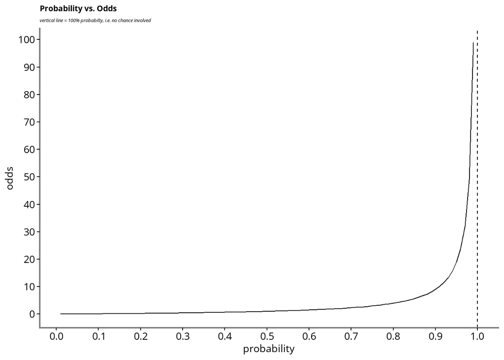